# Case Study 1

Jordan Salsman

10/24/2019

### Load following libraries

ggplot2, and ggthemes - visualizations  
tidyverse  
naniar and visdat - visualizations for missing data  
mice and VIM - Imputation  
GGally, ggmap,treemapify, and lattice - visualizations  
stringr - regular expressions  
class and klaR - classificiation functions  
e1071 - Confusion Matrix  
ROCR - ROC Curve  
openintro - state to abbrevation function  
caret - Regression

### Load data into memory from csv

Load Breweries from csv  
Load Beers from csv  
Merge Breweries and Beers by the Brewery  
Rename Names column after merging two datasets

```r
breweries_ds <- read.csv("/Users/jordansalsman/Desktop/Breweries.csv", strip.white = TRUE)
beers_ds     <- read.csv("/Users/jordansalsman/Desktop/Beers.csv", strip.white= TRUE)
bmerged_ds   <- merge(breweries_ds,beers_ds,by.x="Brew_ID",by.y="Brewery_id")
names(bmerged_ds)[2] <- "BreweryName"
names(bmerged_ds)[5] <- "BeerName"
```

### Structures of the datasets

breweries_ds - Breweries in USA  
beers_ds - Different beer styles with ABV and IBU and Ounces  
bmerged_ds - Merged dataset

```r
str(breweries_ds)
```

```
## 'data.frame':    558 obs. of  4 variables:
##  $ Brew_ID: int  1 2 3 4 5 6 7 8 9 10 ...
##  $ Name   : Factor w/ 551 levels "10 Barrel Brewing Company",..: 355 12 266 319 201 136 227 477 59 491 ...
##  $ City   : Factor w/ 384 levels "Abingdon","Abita Springs",..: 228 200 122 299 300 62 91 48 152 136 ...
##  $ State  : Factor w/ 51 levels "AK","AL","AR",..: 24 18 20 5 5 41 6 23 23 23 ...
```

```r
str(beers_ds)
```

```
## 'data.frame':    2410 obs. of  7 variables:
##  $ Name      : Factor w/ 2304 levels "#001 Golden Amber Lager",..: 1637 576 1703 1841 1818 267 1159 757 1092 485 ...
##  $ Beer_ID   : int  1436 2265 2264 2263 2262 2261 2260 2259 2258 2131 ...
##  $ ABV       : num  0.05 0.066 0.071 0.09 0.075 0.077 0.045 0.065 0.055 0.086 ...
##  $ IBU       : int  NA NA NA NA NA NA NA NA NA NA ...
##  $ Brewery_id: int  409 178 178 178 178 178 178 178 178 178 ...
##  $ Style     : Factor w/ 100 levels "","Abbey Single Ale",..: 19 18 16 12 16 80 18 22 18 12 ...
##  $ Ounces    : num  12 12 12 12 12 12 12 12 12 12 ...
```

```r
str(bmerged_ds)
```

```
## 'data.frame':    2410 obs. of  10 variables:
##  $ Brew_ID    : int  1 1 1 1 1 1 2 2 2 2 ...
##  $ BreweryName: Factor w/ 551 levels "10 Barrel Brewing Company",..: 355 355 355 355 355 355 12 12 12 12 ...
##  $ City       : Factor w/ 384 levels "Abingdon","Abita Springs",..: 228 228 228 228 228 228 200 200 200 200 ...
##  $ State      : Factor w/ 51 levels "AK","AL","AR",..: 24 24 24 24 24 24 18 18 18 18 ...
##  $ BeerName   : Factor w/ 2304 levels "#001 Golden Amber Lager",..: 1639 1925 1524 801 1257 2184 71 457 1217 43 ...
##  $ Beer_ID    : int  2689 2688 2687 2692 2691 2690 2683 2686 2685 2684 ...
##  $ ABV        : num  0.06 0.06 0.056 0.045 0.049 0.048 0.042 0.08 0.125 0.077 ...
##  $ IBU        : int  38 25 47 50 26 19 42 68 80 25 ...
##  $ Style      : Factor w/ 100 levels "","Abbey Single Ale",..: 83 22 57 16 77 48 18 12 46 77 ...
##  $ Ounces     : num  16 16 16 16 16 16 16 16 16 16 ...
```

### Merged dataset

```r
head(bmerged_ds)
```

```
##   Brew_ID       BreweryName        City State      BeerName Beer_ID   ABV
## 1       1 NorthGate Brewing Minneapolis    MN       Pumpion    2689 0.060
## 2       1 NorthGate Brewing Minneapolis    MN    Stronghold    2688 0.060
## 3       1 NorthGate Brewing Minneapolis    MN   Parapet ESB    2687 0.056
## 4       1 NorthGate Brewing Minneapolis    MN  Get Together    2692 0.045
## 5       1 NorthGate Brewing Minneapolis    MN Maggie's Leap    2691 0.049
## 6       1 NorthGate Brewing Minneapolis    MN    Wall's End    2690 0.048
##   IBU                               Style Ounces
## 1  38                         Pumpkin Ale     16
## 2  25                     American Porter     16
## 3  47 Extra Special / Strong Bitter (ESB)     16
## 4  50                        American IPA     16
## 5  26                  Milk / Sweet Stout     16
## 6  19                   English Brown Ale     16
```

```r
tail(bmerged_ds)
```

```
##      Brew_ID                   BreweryName          City State
## 2405     556         Ukiah Brewing Company         Ukiah    CA
## 2406     557       Butternuts Beer and Ale Garrattsville    NY
## 2407     557       Butternuts Beer and Ale Garrattsville    NY
## 2408     557       Butternuts Beer and Ale Garrattsville    NY
## 2409     557       Butternuts Beer and Ale Garrattsville    NY
## 2410     558 Sleeping Lady Brewing Company     Anchorage    AK
##                       BeerName Beer_ID   ABV IBU                   Style
## 2405             Pilsner Ukiah      98 0.055  NA         German Pilsener
## 2406         Porkslap Pale Ale      49 0.043  NA American Pale Ale (APA)
## 2407           Snapperhead IPA      51 0.068  NA            American IPA
## 2408         Moo Thunder Stout      50 0.049  NA      Milk / Sweet Stout
## 2409  Heinnieweisse Weissebier      52 0.049  NA              Hefeweizen
## 2410 Urban Wilderness Pale Ale      30 0.049  NA        English Pale Ale
##      Ounces
## 2405     12
## 2406     12
## 2407     12
## 2408     12
## 2409     12
## 2410     12
```

### Summary Statistics of both datasets

breweries_ds - Breweries in USA  
beers_ds - Different beer styles with ABV and IBU  
bmerged_ds - Merged dataset

```r
summary(breweries_ds)
```

```
##     Brew_ID                           Name           City
##  Min.   :  1.0   Blackrocks Brewery     :  2   Portland: 17
##  1st Qu.:140.2   Blue Mountain Brewery  :  2   Boulder :  9
##  Median :279.5   Lucette Brewing Company:  2   Chicago :  9
##  Mean   :279.5   Oskar Blues Brewery    :  2   Seattle :  9
##  3rd Qu.:418.8   Otter Creek Brewing    :  2   Austin  :  8
##  Max.   :558.0   Sly Fox Brewing Company:  2   Denver  :  8
##                  (Other)                :546   (Other) :498
##      State
##  CO     : 47
##  CA     : 39
##  MI     : 32
##  OR     : 29
##  TX     : 28
##  PA     : 25
##  (Other):358
```

```r
summary(beers_ds)
```

```
##                      Name         Beer_ID            ABV
##  Nonstop Hef Hop       :  12   Min.   :   1.0   Min.   :0.00100
##  Dale's Pale Ale       :   6   1st Qu.: 808.2   1st Qu.:0.05000
##  Oktoberfest           :   6   Median :1453.5   Median :0.05600
##  Longboard Island Lager:   4   Mean   :1431.1   Mean   :0.05977
##  1327 Pod's ESB        :   3   3rd Qu.:2075.8   3rd Qu.:0.06700
##  Boston Lager          :   3   Max.   :2692.0   Max.   :0.12800
##  (Other)               :2376                    NA's   :62
##       IBU           Brewery_id                               Style
##  Min.   :  4.00   Min.   :  1.0   American IPA                  : 424
##  1st Qu.: 21.00   1st Qu.: 94.0   American Pale Ale (APA)       : 245
##  Median : 35.00   Median :206.0   American Amber / Red Ale      : 133
##  Mean   : 42.71   Mean   :232.7   American Blonde Ale           : 108
##  3rd Qu.: 64.00   3rd Qu.:367.0   American Double / Imperial IPA: 105
##  Max.   :138.00   Max.   :558.0   American Pale Wheat Ale       :  97
##  NA's   :1005                     (Other)                       :1298
##      Ounces
##  Min.   : 8.40
##  1st Qu.:12.00
##  Median :12.00
##  Mean   :13.59
##  3rd Qu.:16.00
##  Max.   :32.00
##
```

```r
summary(bmerged_ds)
```

```
##     Brew_ID                          BreweryName             City
##  Min.   :  1.0   Brewery Vivant            :  62   Grand Rapids:  66
##  1st Qu.: 94.0   Oskar Blues Brewery       :  46   Portland    :  64
##  Median :206.0   Sun King Brewing Company  :  38   Chicago     :  55
##  Mean   :232.7   Cigar City Brewing Company:  25   Indianapolis:  43
##  3rd Qu.:367.0   Sixpoint Craft Ales       :  24   San Diego   :  42
##  Max.   :558.0   Hopworks Urban Brewery    :  23   Boulder     :  41
##                  (Other)                   :2192   (Other)     :2099
##      State                        BeerName       Beer_ID
##  CO     : 265   Nonstop Hef Hop       :  12   Min.   :   1.0
##  CA     : 183   Dale's Pale Ale       :   6   1st Qu.: 808.2
##  MI     : 162   Oktoberfest           :   6   Median :1453.5
##  IN     : 139   Longboard Island Lager:   4   Mean   :1431.1
##  TX     : 130   1327 Pod's ESB        :   3   3rd Qu.:2075.8
##  OR     : 125   Boston Lager          :   3   Max.   :2692.0
##  (Other):1406   (Other)               :2376
##       ABV               IBU                                    Style
##  Min.   :0.00100   Min.   :  4.00   American IPA                  : 424
##  1st Qu.:0.05000   1st Qu.: 21.00   American Pale Ale (APA)       : 245
##  Median :0.05600   Median : 35.00   American Amber / Red Ale      : 133
##  Mean   :0.05977   Mean   : 42.71   American Blonde Ale           : 108
##  3rd Qu.:0.06700   3rd Qu.: 64.00   American Double / Imperial IPA: 105
##  Max.   :0.12800   Max.   :138.00   American Pale Wheat Ale       :  97
##  NA's   :62        NA's   :1005     (Other)                       :1298
##      Ounces
##  Min.   : 8.40
##  1st Qu.:12.00
##  Median :12.00
##  Mean   :13.59
##  3rd Qu.:16.00
##  Max.   :32.00
##
```

### Visual Summary

Total Breweries per state  
Bar Chart

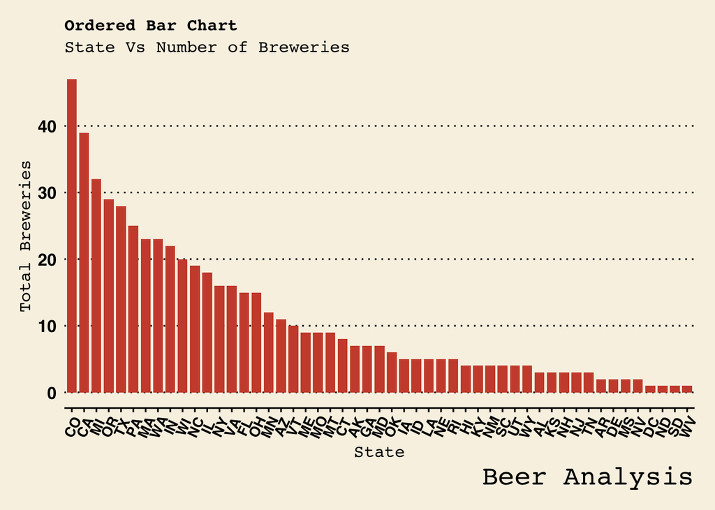

```r
b_states <- breweries_ds %>% group_by(State) %>% count() %>% arrange(desc(n))
b_states$State <- factor(b_states$State, levels = b_states$State)
ggplot(b_states, aes(x=State, y=n)) +
  geom_bar(stat="identity", width=.8, fill="tomato3") +
  labs(title="Ordered Bar Chart",
       subtitle="State Vs Number of Breweries",
       caption="Beer Analysis") +
  xlab("State")+
  ylab("Total Breweries")+
  theme_wsj()+
  theme(axis.text.x = element_text(angle=65, vjust=0.6))+
  theme(plot.title    = element_text(size = rel(0.5)),
  plot.subtitle = element_text(size = rel(0.5)),
  axis.text.x   = element_text(vjust=0.6,size=10),
  axis.title    = element_text(size = rel(0.5)),
  legend.position  = "right",
  legend.direction ="vertical",
  legend.title = element_text(size = rel(0.2)))
```

### More Visual Summary

Heat Map of Breweries per state

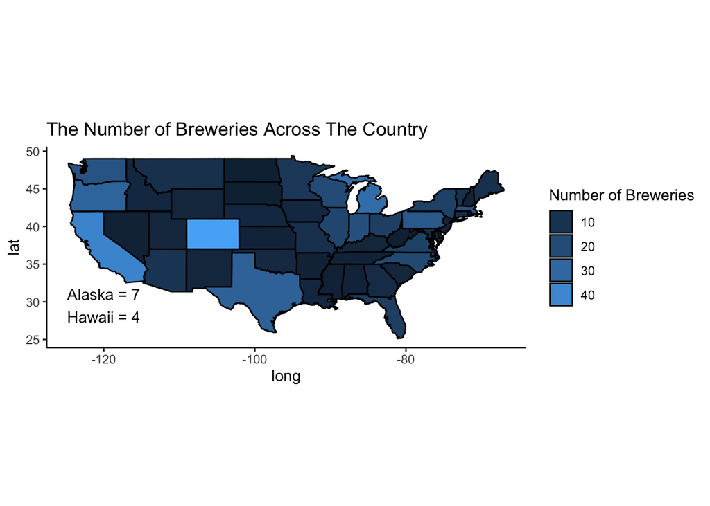

```r
states <- map_data("state")
states$region <- state2abbr(states$region)
colnames(states)[colnames(states)=="region"] <- "State"
Brew_count <- breweries_ds %>% group_by(State) %>% count(State)
full <- merge(x = states, y = Brew_count, by = "State")
ggplot() +
 geom_polygon(data=full, aes(x=long, y=lat, group = group, fill = n),colour="black")+
 coord_fixed()+ guides(fill=guide_legend(title="Number of Breweries")) + theme_classic() +     ggtitle("The Number of Breweries Across The Country") + annotate("text",x = -120, y = 31, label = "Alaska = 7") + annotate("text",x = -120, y = 28, label = "Hawaii = 4") + geom_text(label = n)
```

### Missing Values along State Variable

breweris_ds - Breweries in USA  
beers_ds - Different beer styles with ABV and IBU  
—Not randomly missing throughout

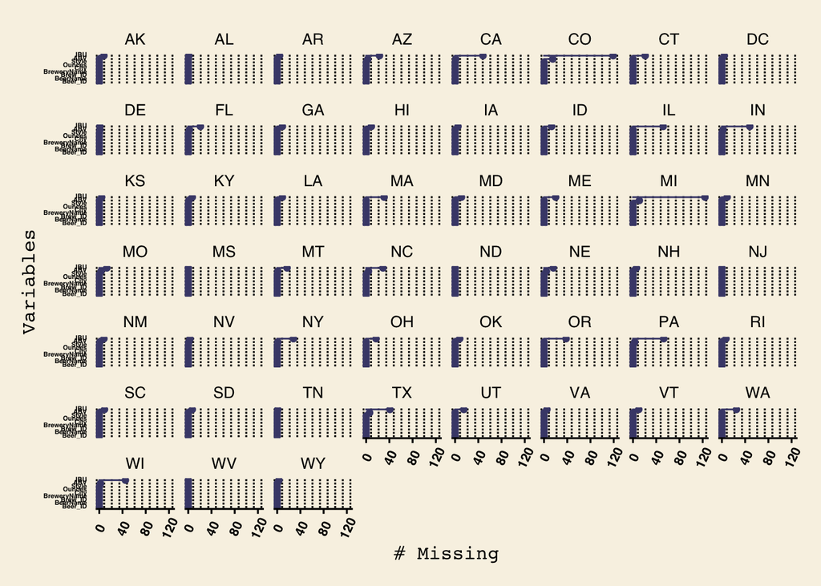

```r
beer_ounces <- beers_ds
beer_ounces$Ounces <- as.factor(beer_ounces$Ounces)
gg_miss_var(bmerged_ds,facet=State)+
  theme_wsj()+
  theme(axis.text.x = element_text(angle=65, vjust=0.3))+
  theme(plot.title    = element_text(size = rel(0.5)),
  plot.subtitle = element_text(size = rel(0.5)),
  axis.text.x   = element_text(vjust=0.6,size=8),
  axis.text.y   = element_text(vjust=0.2,size=4),
  axis.title    = element_text(size = rel(0.5)),
  legend.position  = "right",
  legend.direction ="vertical",
  legend.title = element_text(size = rel(0.2)))
```

### Imputations

62 records doens’t have IBU and SBV both - these are deleted  
Total records to process 2410-62 = 2348  
Prediction is required on 943 missing IBU  
Total records with IBU is 1405  
Replacing with Linear Regression Imputations

```r
bmerged_final_ds <- bmerged_ds %>% filter(!is.na(ABV) | !is.na(IBU))
non_missing_ibu <- bmerged_final_ds %>% filter(!is.na(IBU))
non_missing_ibu$imputed <- "N"
missing_ibu <- bmerged_final_ds %>% filter(is.na(IBU))
missing_ibu$imputed <- "Y"
model_ibu <- non_missing_ibu %>% lm(formula=log(IBU)~log(ABV))
summary(model_ibu)
```

```
##
## Call:
## lm(formula = log(IBU) ~ log(ABV), data = .)
##
## Residuals:
##      Min       1Q   Median       3Q      Max
## -2.81374 -0.30156  0.08312  0.38514  1.35081
##
## Coefficients:
##             Estimate Std. Error t value Pr(>|t|)
## (Intercept)  8.99667    0.18115   49.66   <2e-16 ***
## log(ABV)     1.91683    0.06363   30.12   <2e-16 ***
## ---
## Signif. codes:  0 '***' 0.001 '**' 0.01 '*' 0.05 '.' 0.1 ' ' 1
##
## Residual standard error: 0.514 on 1403 degrees of freedom
## Multiple R-squared:  0.3927, Adjusted R-squared:  0.3923
## F-statistic: 907.4 on 1 and 1403 DF,  p-value: < 2.2e-16
```

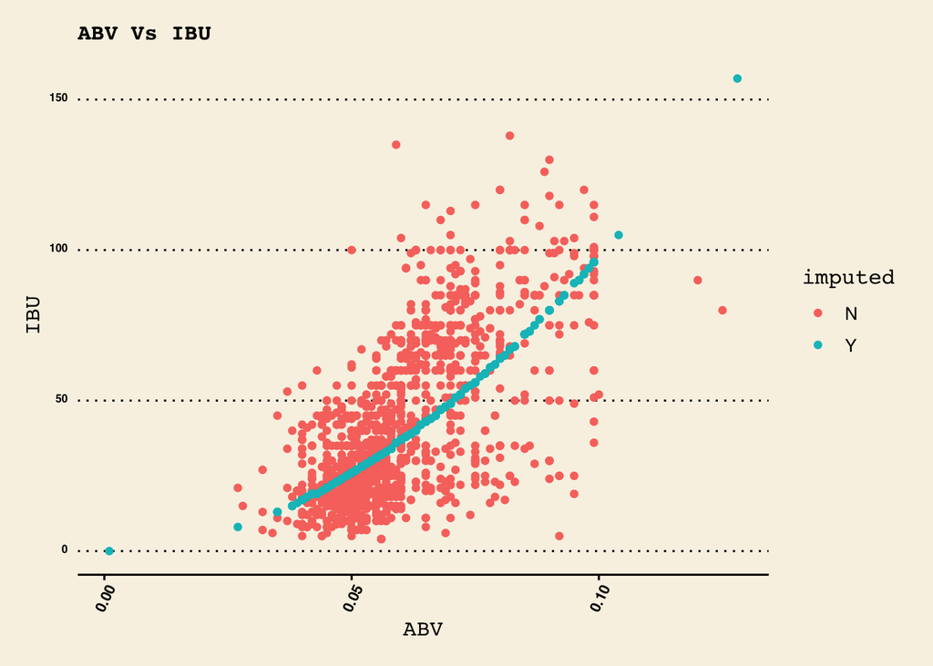

```r
missing_ibu$IBU <- round(exp(predict(model_ibu,missing_ibu)),0)
imputed_df <- rbind(non_missing_ibu,missing_ibu)
imputed_df$imputed <- as.factor(imputed_df$imputed)
imputed_df %>% ggplot(aes(x=ABV,y=IBU,color=imputed))+
               geom_point()+ggtitle("ABV Vs IBU") +
               theme_wsj()+
               theme(axis.text.x = element_text(angle=65, vjust=0.3))+
               theme(plot.title    = element_text(size = rel(0.5)),
               plot.subtitle = element_text(size = rel(0.5)),
               axis.text.x   = element_text(vjust=0.6,size=8),
               axis.text.y   = element_text(vjust=0.2,size=6),
               axis.title    = element_text(size = rel(0.5)),
               legend.position  = "right",
               legend.direction ="vertical",
               legend.title = element_text(size = rel(0.5)))
```

### State Vs Median ABV Bar Chart

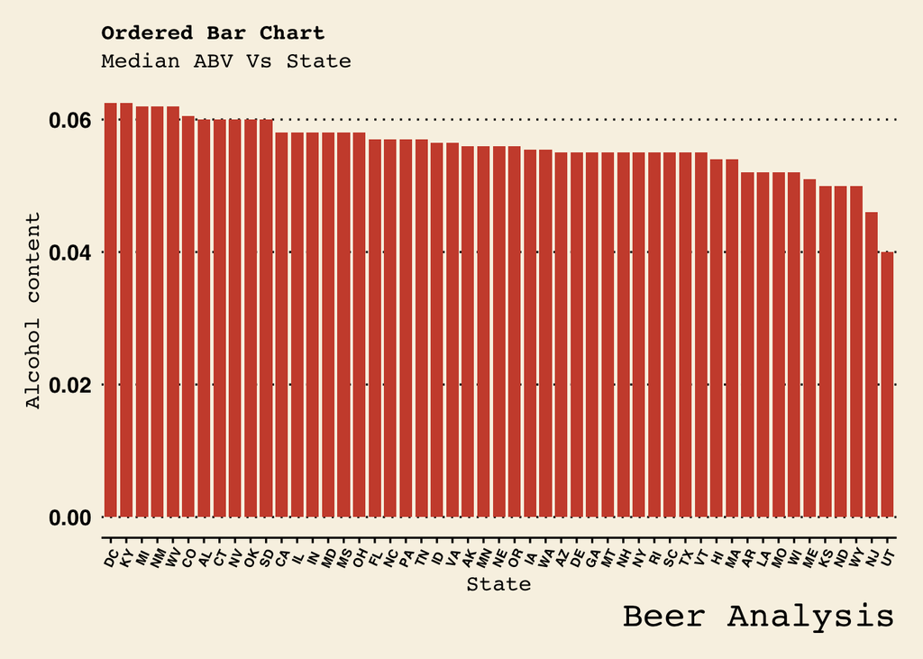

```r
abv_by_states <- imputed_df  %>% group_by(State) %>%  summarise(Median=as.numeric(median(ABV))) %>% arrange(desc(Median))
abv_by_states$State <- factor(abv_by_states$State, levels = abv_by_states$State)
ggplot(abv_by_states, aes(x=State, y=Median)) +
  geom_bar(stat="identity", width=.8, fill="tomato3") +
  labs(title="Ordered Bar Chart",
       subtitle="Median ABV Vs State",
       caption="Beer Analysis") +
  xlab("State")+
  ylab("Alcohol content")+
  theme_wsj()+
  theme(axis.text.x = element_text(angle=65, vjust=0.6))+
  theme(plot.title    = element_text(size = rel(0.5)),
  plot.subtitle = element_text(size = rel(0.5)),
  axis.text.x   = element_text(vjust=0.6,size=7),
  axis.title    = element_text(size = rel(0.5)),
  legend.position  = "right",
  legend.direction ="vertical",
  legend.title = element_text(size = rel(0.2)))
```

### State Vs Median Bitterness Barchart

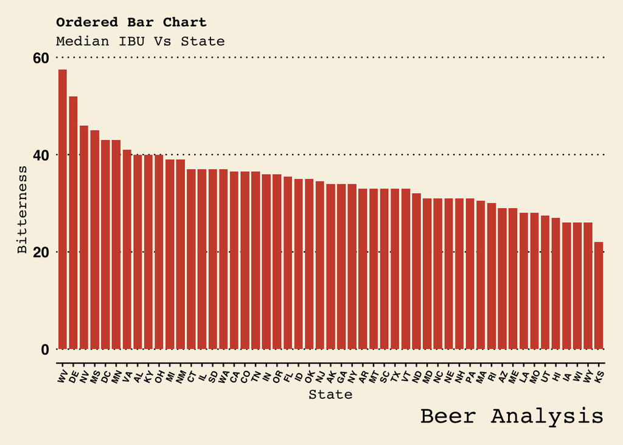

```r
ibu_by_states <- imputed_df %>% group_by(State) %>%  summarise(Median=as.numeric(median(IBU))) %>% arrange(desc(Median))
ibu_by_states$State <- factor(ibu_by_states$State, levels = ibu_by_states$State)
ggplot(ibu_by_states, aes(x=State, y=Median)) +
  geom_bar(stat="identity", width=.8, fill="tomato3") +
  labs(title="Ordered Bar Chart",
       subtitle="Median IBU Vs State",
       caption="Beer Analysis") +
  xlab("State")+
  ylab("Bitterness")+
  theme_wsj()+
  theme(axis.text.x = element_text(angle=65, vjust=0.6))+
  theme(plot.title    = element_text(size = rel(0.5)),
  plot.subtitle = element_text(size = rel(0.5)),
  axis.text.x   = element_text(vjust=0.6,size=7),
  axis.title    = element_text(size = rel(0.5)),
  legend.position  = "right",
  legend.direction ="vertical",
  legend.title = element_text(size = rel(0.2)))
```

### Max ABV

```r
max(imputed_df$ABV)
```

```
## [1] 0.128
```

```r
which.max(imputed_df$ABV)
```

```
## [1] 1569
```

```r
print(imputed_df[1569,])
```

```
##      Brew_ID             BreweryName    City State
## 1569      52 Upslope Brewing Company Boulder    CO
##                                                  BeerName Beer_ID   ABV
## 1569 Lee Hill Series Vol. 5 - Belgian Style Quadrupel Ale    2565 0.128
##      IBU            Style Ounces imputed
## 1569 157 Quadrupel (Quad)   19.2       Y
```

### Distribution of ABV

Boxplot ABV

```r
ibu_by_states <- imputed_df %>% group_by(State) %>%  arrange(desc(ABV))
ibu_by_states$State <- factor(ibu_by_states$State, levels = unique(ibu_by_states$State))
str(ibu_by_states)
```

[output not shown]

[output cut: 12 more lines]

[output not shown]

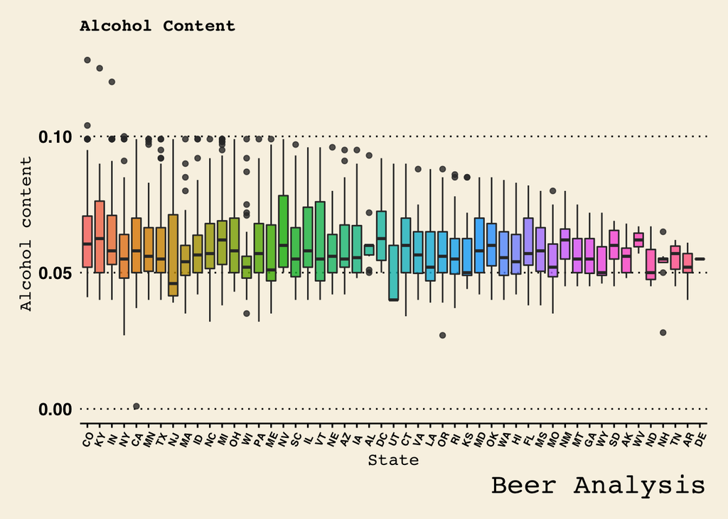

```r
ibu_by_states %>% ggplot(aes(y=ABV,x=State)) +
                  geom_boxplot(aes(fill=State), alpha=0.8,show.legend = FALSE) +
                  labs(title="Alcohol Content",
                  caption="Beer Analysis") +
                  xlab("State")+
                  ylab("Alcohol content")+
                  theme_wsj()+
                  theme(axis.text.x = element_text(angle=65, vjust=0.6))+
                  theme(plot.title    = element_text(size = rel(0.5)),
                  plot.subtitle = element_text(size = rel(0.5)),
                  axis.text.x   = element_text(vjust=0.6,size=7),
                  axis.title    = element_text(size = rel(0.5)),
                  legend.position  = "right",
                  legend.direction ="vertical",
                  legend.title = element_text(size = rel(0.2)))
```

### Max IBU

```r
max(imputed_df$IBU)
```

```
## [1] 157
```

```r
which.max(imputed_df$IBU)
```

```
## [1] 1569
```

```r
print(imputed_df[1569,])
```

```
##      Brew_ID             BreweryName    City State
## 1569      52 Upslope Brewing Company Boulder    CO
##                                                  BeerName Beer_ID   ABV
## 1569 Lee Hill Series Vol. 5 - Belgian Style Quadrupel Ale    2565 0.128
##      IBU            Style Ounces imputed
## 1569 157 Quadrupel (Quad)   19.2       Y
```

### Distribution of IBU

Boxplot IBU

```r
ibu_by_states <- imputed_df  %>% group_by(State) %>%  arrange(desc(IBU))
ibu_by_states$State <- factor(ibu_by_states$State, levels = unique(ibu_by_states$State))
str(ibu_by_states)
```

[output not shown]

[output cut: 12 more lines]

[output not shown]

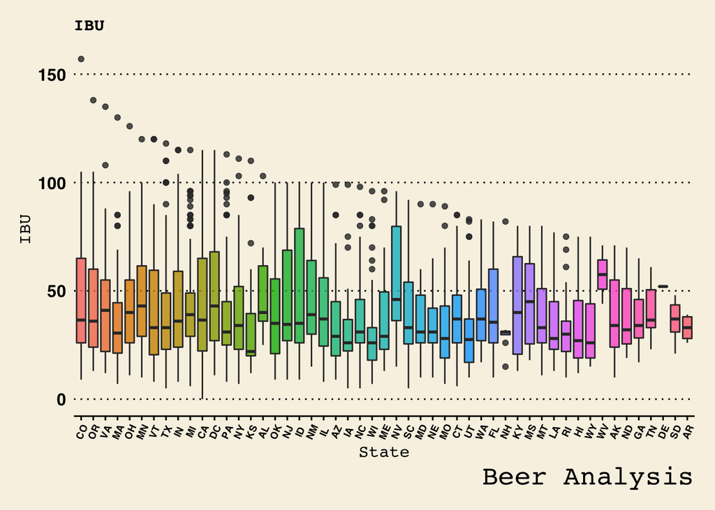

```r
ibu_by_states %>% ggplot(aes(y=IBU,x=State)) +
                  geom_boxplot(aes(fill=State), alpha=0.8,show.legend = FALSE) +
                  labs(title="IBU",
                  caption="Beer Analysis") +
                  xlab("State")+
                  ylab("IBU")+
                  theme_wsj()+
                  theme(axis.text.x = element_text(angle=65, vjust=0.6))+
                  theme(plot.title    = element_text(size = rel(0.5)),
                  plot.subtitle = element_text(size = rel(0.5)),
                  axis.text.x   = element_text(vjust=0.6,size=7),
                  axis.title    = element_text(size = rel(0.5)),
                  legend.position  = "right",
                  legend.direction ="vertical",
                  legend.title = element_text(size = rel(0.2)))
```

### Summary Statistics of ABV

Density plot and Histogram of ABV Distribition

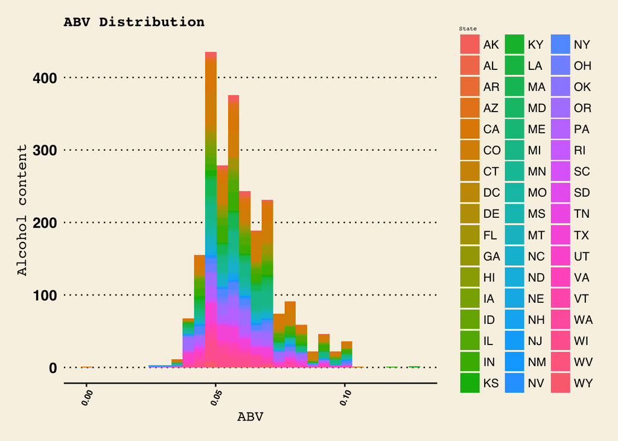

```r
imputed_df %>% ggplot(aes(x=ABV, fill = State)) +
               geom_histogram(bins=30) +
               labs(title="ABV Distribution"
               ) +
               ylab("Alcohol content")+
               theme_wsj()+
               theme(axis.text.x = element_text(angle=65, vjust=0.6))+
               theme(plot.title    = element_text(size = rel(0.5)),
               plot.subtitle = element_text(size = rel(0.5)),
               axis.text.x   = element_text(vjust=0.6,size=7),
               axis.title    = element_text(size = rel(0.5)),
               legend.position  = "right",
               legend.direction ="vertical",
               legend.title = element_text(size = rel(0.2)))
```

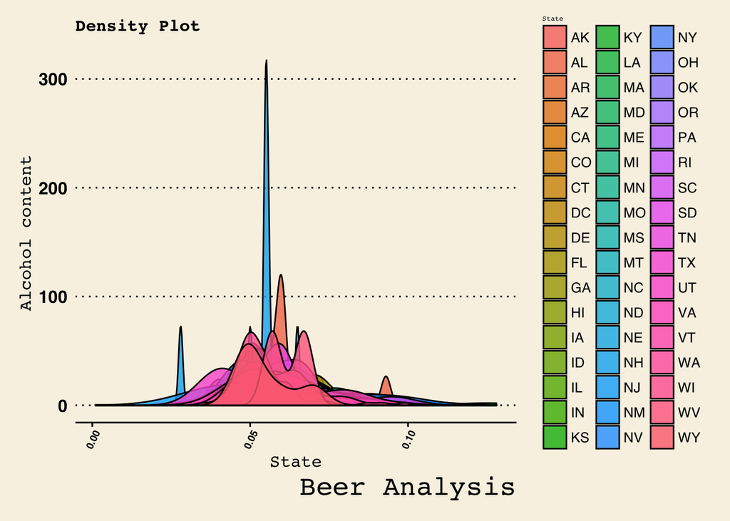

```r
imputed_df %>% ggplot(aes(x=ABV)) +
               geom_density(aes(fill=State), alpha=0.8) +
               labs(title="Density Plot",
               caption="Beer Analysis") +
               xlab("State")+
               ylab("Alcohol content")+
               theme_wsj()+
               theme(axis.text.x = element_text(angle=65, vjust=0.6))+
               theme(plot.title    = element_text(size = rel(0.5)),
               plot.subtitle = element_text(size = rel(0.5)),
               axis.text.x   = element_text(vjust=0.6,size=7),
               axis.title    = element_text(size = rel(0.5)),
               legend.position  = "right",
               legend.direction ="vertical",
               legend.title = element_text(size = rel(0.2)))
```

```r
summary(imputed_df$ABV)
```

```
##    Min. 1st Qu.  Median    Mean 3rd Qu.    Max.
## 0.00100 0.05000 0.05600 0.05977 0.06700 0.12800
```

### Scatterplot and Correlation of ABV vs IBU

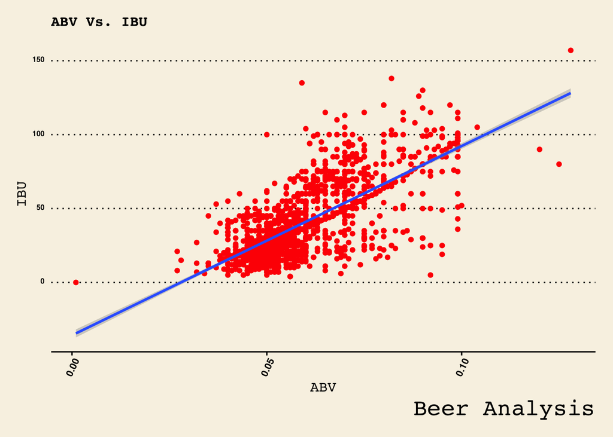

```r
imputed_df %>% ggplot(aes(x=ABV,y=IBU))+
               geom_point(color = "Red")+
               theme_wsj()+
               geom_smooth(method="lm")+
               labs(title="ABV Vs. IBU",
               caption="Beer Analysis") +
               theme(axis.text.x = element_text(angle=65, vjust=0.3))+
               theme(plot.title    = element_text(size = rel(0.5)),
               plot.subtitle = element_text(size = rel(0.5)),
               axis.text.x   = element_text(vjust=0.6,size=8),
               axis.text.y   = element_text(vjust=0.2,size=6),
               axis.title    = element_text(size = rel(0.5)),
               legend.position  = "right",
               legend.direction ="vertical",
               legend.title = element_text(size = rel(0.5)))
```

```r
cor(imputed_df$ABV,imputed_df$IBU)
```

```
## [1] 0.753397
```

### KNN with Cross-validation and K-Tuning

Confusion Matrix  
K Hyper-Parameter tuning plot

```r
library(e1071)
imputed_df$Style <- toupper(imputed_df$Style)
IPA <- imputed_df %>% filter(str_detect(Style, "IPA"))
IPA$Style <- "IPA"
ALE <- imputed_df %>% filter(str_detect(Style, "IPA" , negate = TRUE)) %>% filter(str_detect(Style, "ALE"))
ALE$Style <- "Ale"
mod_df <- rbind(IPA, ALE)

set.seed(7)
iterations = 100
k = 30
Acc_holder = matrix(nrow = iterations, ncol = k)
for(j in 1:iterations)
{
smp <- floor(0.75 * nrow(mod_df))
train_ind <- sample(seq_len(nrow(mod_df)), size = smp)
imputed_train <- mod_df[train_ind, ]
imputed_test <- mod_df[-train_ind, ]
  for(i in 1:k)
  {
  classifications <- knn(imputed_train[,c(7,8)], imputed_test[,c(7,8)], imputed_train$Style,     prob = TRUE, k = i)
  CM <- confusionMatrix(table(classifications, imputed_test$Style))
    Acc_holder[j,i] = CM$overall[1]
  }
}
MeanAcc = colMeans(Acc_holder)
which.max(MeanAcc)
```

```
## [1] 7
```

```r
k <- c(1:30)
Mean_Acc_df <- data_frame(MeanAcc)
```

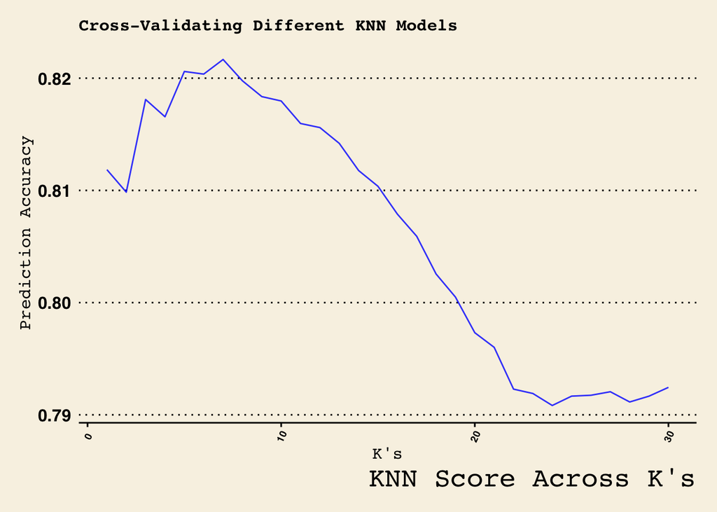

```r
Mean_Acc_df <- cbind(k, Mean_Acc_df)
Mean_Acc_df %>% ggplot(aes(x = k, y= MeanAcc)) +
               geom_line(color = "blue", alpha = .8) +
               labs(title="Cross-Validating Different KNN Models",
               caption="KNN Score Across K's") +
               xlab("K's")+
               ylab("Prediction Accuracy")+
               theme_wsj()+
               theme(axis.text.x = element_text(angle=65, vjust=0.6))+
               theme(plot.title    = element_text(size = rel(0.5)),
               plot.subtitle = element_text(size = rel(0.5)),
               axis.text.x   = element_text(vjust=0.6,size=7),
               axis.title    = element_text(size = rel(0.5)),
               legend.position  = "right",
               legend.direction ="vertical",
               legend.title = element_text(size = rel(0.2)))
```

```r
classifications <- knn(imputed_train[,c(7,8)], imputed_test[,c(7,8)], imputed_train$Style,     prob = TRUE, k = 6)
CM <- confusionMatrix(table(classifications, imputed_test$Style))
CM
```

```
## Confusion Matrix and Statistics
##
##
## classifications Ale IPA
##             Ale 205  31
##             IPA  41 107
##
##                Accuracy : 0.8125
##                  95% CI : (0.7698, 0.8503)
##     No Information Rate : 0.6406
##     P-Value [Acc > NIR] : 1.206e-13
##
##                   Kappa : 0.5992
##
##  Mcnemar's Test P-Value : 0.2888
##
##             Sensitivity : 0.8333
##             Specificity : 0.7754
##          Pos Pred Value : 0.8686
##          Neg Pred Value : 0.7230
##              Prevalence : 0.6406
##          Detection Rate : 0.5339
##    Detection Prevalence : 0.6146
##       Balanced Accuracy : 0.8043
##
##        'Positive' Class : Ale
##
```

### Further exploration

Separating Beers into known Light and Dark  
—Only Beers that are definitely Light or Dark are used

```r
imputed_df$Style <- toupper(imputed_df$Style)
Blonde <- imputed_df %>%filter(str_detect(Style, "BLONDE"))
Blonde$Style <- "Light"
Light <- imputed_df %>%filter(str_detect(Style, "LIGHT"))
Light$Style <- "Light"
Cream <- imputed_df %>%filter(str_detect(Style, "CREAM"))
Cream$Style <- "Light"
Shandy <- imputed_df %>%filter(str_detect(Style, "SHANDY"))
Shandy$Style <- "Light"
Porter <- imputed_df %>%filter(str_detect(Style, "PORTER"))
Porter$Style <- "Dark"
Stout <- imputed_df %>%filter(str_detect(Style, "STOUT"))
Stout$Style <- "Dark"
Dark <- imputed_df %>%filter(str_detect(Style, "DARK"))
Dark$Style <- "Dark"
Black <- imputed_df %>%filter(str_detect(Style, "BLACK"))
Black$Style <- "Dark"
color <- rbind(Blonde,Light,Porter,Stout,Dark,Black,Cream,Shandy)
```

### Using Naive Bayes to classify Light Vs. Dark Beers

ROC Curve plot  
Confusion Matrix

```r
iterations = 100
AccHolder = numeric(100)
SensHolder = numeric(100)
SpecHolder = numeric(100)
for(seed in 1:iterations)
{
  set.seed(seed)
    Indices = sample(seq(1:length(color$Style)),round(.75*length(color$Style)))
    train_color = color[Indices,]
    test_color = color[-Indices,]
    model = naiveBayes(train_color[,c("ABV", "IBU", "State")],factor(train_color$Style, labels     = c("Light", "Dark")))
    CM = confusionMatrix(table(factor(test_color$Style, labels = c("Light",   "Dark")),predict(model,test_color[,c("ABV", "IBU", "State")])))
    AccHolder[seed] = CM$overall[1]
    SensHolder[seed] = CM$byClass[1]
    SpecHolder[seed] = CM$byClass[2]
}
mean(AccHolder)
```

```
## [1] 0.7730526
```

```r
mean(SensHolder)
```

```
## [1] 0.9046627
```

```r
mean(SpecHolder)
```

```
## [1] 0.6568694
```

```r
which.max(AccHolder)
```

```
## [1] 84
```

```r
which.max(SensHolder)
```

```
## [1] 2
```

```r
which.max(SpecHolder)
```

```
## [1] 100
```

```r
set.seed(38)
Indices = sample(seq(1:length(color$Style)),round(.75*length(color$Style)))
train_color = color[Indices,]
test_color = color[-Indices,]
model = naiveBayes(train_color[,c("ABV", "IBU", "State")],factor(train_color$Style, labels = c("Light", "Dark")))
CM = confusionMatrix(table(factor(test_color$Style, labels = c("Light", "Dark")),predict(model,test_color[,c("ABV", "IBU", "State")])))
CM
```

```
## Confusion Matrix and Statistics
##
##
##         Light Dark
##   Light    39   16
##   Dark      5   35
##
##                Accuracy : 0.7789
##                  95% CI : (0.6822, 0.8577)
##     No Information Rate : 0.5368
##     P-Value [Acc > NIR] : 8.711e-07
##
##                   Kappa : 0.563
##
##  Mcnemar's Test P-Value : 0.0291
##
##             Sensitivity : 0.8864
##             Specificity : 0.6863
##          Pos Pred Value : 0.7091
##          Neg Pred Value : 0.8750
##              Prevalence : 0.4632
##          Detection Rate : 0.4105
##    Detection Prevalence : 0.5789
##       Balanced Accuracy : 0.7863
##
##        'Positive' Class : Light
##
```

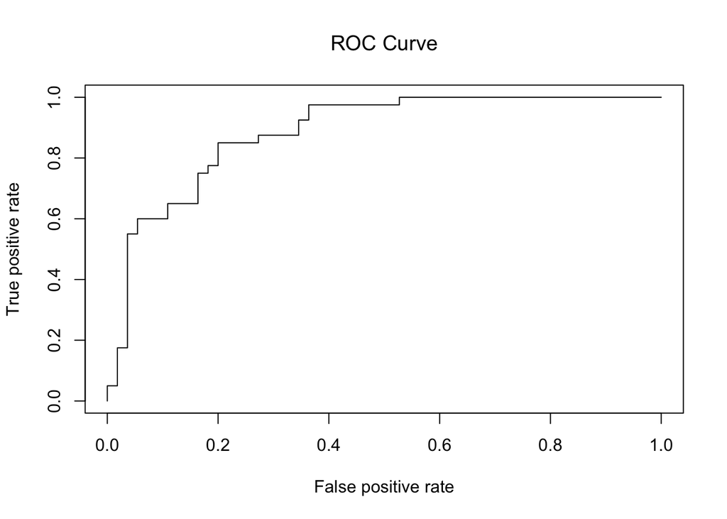

```r
pred_nb <- predict(model,test_color[,c("ABV", "IBU", "State")], type = 'raw')
pred <- prediction(pred_nb[, 2], test_color$Style)
nb.prff = performance(pred, "tpr", "fpr")
plot(nb.prff,main="ROC Curve")
```